# Clear-cutting

NO_AIFH_001

Authors

Affiliations

Aud Helen Halbritter

University of Bergen

Ken Olaf Storaunet

Norwegian Institute of Bioeconomy Research

Mari Jönsson

Norwegian Institute for Nature Research

Oliver Snoksrud

Norwegian Institute of Bioeconomy Research

Ulrika Jansson Asplund

Norwegian Institute for Nature Research

Published

June 9, 2026

Reviewed by

Matthew Grainger

> **Recommended citation**: Halbritter, A. H., Storaunet, K. O., Jönsson, M., Snoksrud, O., and Jansson Asplund, U. 2026. Clear-cutting (ID(s): NO_AIFH_001) v. 0.1.0. ecRxiv: https://github.com/NINAnor/ecRxiv/tree/main/indicators/NO_AIFH_001

**Metadata**

Table 1: Indicator metadata

[output not shown]

**Log**

- 09 Jun. 2026 - NO_AIFH_001, ecTools workflow
- 18 July 2026 - Accepted
- 10 August 2026 - Minor update to metadata

## 2. About the underlying data

### 2.1 Spatial and temporal extent, resolution, and representativity

The indicator is based on plot-level data from the Norwegian National Forest Inventory (NFI), covering Norwegian forest land. The underlying data is available from 2018 onwards. The indicator is therefore reported for a single five-year period, 2020–2024. Earlier periods might be added if FLATEHOGD becomes available for previous years.

### 2.2 Sampling design

Estimates of clear-cut forest area were based on permanent sample plots from the Norwegian National Forest Inventory (NFI). For all plots measured during the 2018–2022 inventory cycle, previous field records and historical aerial photographs were interpreted to determine whether the forest had been subject to clear-cutting or not, back to ca. 1940. Each plot was classified as either clear-cut, not clear-cut or not possible to determine (Viken et al. 2026). 8% of the investigated plots could not be determined because of insufficient historical aerial-photo coverage (Viken et al. 2026).

### 2.4 Instructions for citing, using and accessing data

The data used for this indicator have been made available by the Norwegian National Forest Inventory under a specific data use agreement of 2026-05-29, between NIBIO and the specified users. Further use of these data requires a separate data user agreement with NIBIO.

## 3. Indicator properties

### 3.1 Ecosystem Condition Typology Class (ECT)

C1 Landscape and Seascape Characteristics

### 3.2 Ecosystem condition characteristic

The indicator represents the proportion of not clear-cut forest of the total forest landscape, since such harvesting practices became dominant in Norway after the 1940s. Not clear-cut forests may occur as small and scattered patches in regions with intensive forest management, and as more continuous areas in regions with less intensive forest management. The indicator is assessed as a landscape characteristic (C1) in the ecosystem condition typology.

### 3.3 Collinearities with other indicators

Correlation with other indicators of old forest is expected. Some correlation with habitat indicators (e.g. dead wood, old/large trees) might also be expected.

### 3.4 Impact factors

Clear-cut harvesting is the impact factor for this indicator.

### 3.5 Spatial aggregation

The spatial aggregation pathway is: aggregate (NFI plots to county) – [scale] – aggregate (geographic region) – aggregate (national level). Non-scaled values are area-weighted means of the plot-level `FLATEHOGD` variable. Scaling uses national reference levels X0 = 100% clear-cut area share and X100 = 0% clear-cut area share (proportions 1 and 0 on the original scale).

## 4. Reference condition and levels

### 4.1 Reference condition

The reference condition is considered to be intact forest ecosystems where effects of human activities are clearly subordinate to those of natural ecosystem processes and disturbances.

### 4.2 Reference levels

X0 is set to 100% clear-cut area share (worst condition) and X100 to 0% clear-cut area share (best condition). Values are scaled linearly between X0 and X100 (Section 9.4). Because the non-scaled indicator is an area proportion bounded between 0 and 1 (0%–100% clear-cut), values can not fall outside the reference range and no truncation is needed.

#### 4.2.1 Spatial resolution and validity

Reference levels are defined as one national value for the share of the assessed forest area with no clear-cutting. Although indicator values from NFI plots technically may be aggregated at finer spatial units than counties, scaling at such finer levels may result in biases.

## 5. Uncertainties

### 5.1 General uncertainties

For 8 % of the NFI plots it was not possible to determine if the area had been subjected to clear-cut harvesting or not. These plots were classified as not clear-cut, resulting in a somewhat conservative estimate of the extent of clear-cut forest. Regional and national values are area-weighted summaries of county estimates, and therefore inherit both model uncertainty at county level and any mismatch between county boundaries and ecological variation within regions. The indicator does not account for the intensity and timing of clear-cutting, nor for the size and fragmentation of forests that have not been clear-cut.

### 5.2 Reported uncertainties

County non-scaled values are bootstrapped with 1000 draws per county per period. County draws are scaled using the national *X<sub>0</sub>* and *X<sub>100</sub>*. Uncertainty is propagated when aggregating to regional and national levels.

## 6. References

Viken, K. O., A. Svensson, and J. Breidenbach. 2026. *Omfang av flatehogst etter 1940 i norsk skog – resultater for hele landet*. 12/87. NIBIO. doi:10.21350/7jda-9y78.

## 7. Import and prepare datasets

### 7.1 Share of forest area with clear-cut

**Load data**

```r
lsk_data_file <- here("data/LSK_data_okologisk_tilstand_2026-06-03.csv")

lsk_data_raw <- read_csv(
  lsk_data_file,
  show_col_types = FALSE,
  locale = locale(encoding = "UTF-8")
) |>
  clean_names()
```

## 8. Spatial units

Aggregated indicator values are reported for counties, regions and nationally. Where counties are split into parts, those parts are merged to a single county name before aggregation. Aggregated indicator values should not be applied for spatial units finer than those that allow reliable estimates.

## 9. Analyses

### 9.1 Prepare data and create derived variables

This section prepares the NFI plot data for indicator calculation. We define one five-year reporting period (2020–2024).

**Define reporting periods**

```r
min_indicator_year <- 2020L

reporting_periods <- list(
  # "2010-2014" = 2010:2014,  # enable when data is available
  # "2015-2019" = 2015:2019,  # enable when data is available
  "2020-2024" = 2020:2024
)
```

We filter the raw dataset to inventory years from 2020 onward (`sesong >= min_indicator_year`) and include productive and unproductive forest plots (`arealtype` 1 and 12). Plots with non-missing `flatehogd` (codes 1, 2, or 3) are retained, and split NFI county labels are standardised by merging county parts to a single county name. Code 1 is recoded to 1 (clear-cut); codes 2 and 3 are recoded to 0 (no clear-cutting). For each included plot, the area-weighted contribution to later aggregation is `indicator_continuous * au_areal`.

**Create derived variables**

```r
lsk_data <- lsk_data_raw |>
  filter(sesong >= min_indicator_year) |>
  filter(arealtype %in% c(1, 12)) |>
  filter(!is.na(flatehogd)) |>
  mutate(
    fylke_name = region_fylke |>
      stringr::str_remove("^\\d+-\\d+\\s+") |>
      stringr::str_remove("^\\d+\\s*") |>
      stringr::str_squish(),
    fylke_name = normalize_county_parts(fylke_name),
    fylke_name_clean = stringi::stri_trans_general(
      stringr::str_squish(
        tolower(stringr::str_replace_all(fylke_name, "[0-9.-]", " "))
      ),
      "Latin-ASCII"
    ),
    region_code = assign_region_code(fylke_name_clean),
    region_name = assign_region_name(region_code),
    indicator_continuous = dplyr::if_else(flatehogd == 1, 1, 0),
    indicator_continuous_weighted = indicator_continuous * au_areal
  )
```

Finally, we retain only the columns required for subsequent aggregation and reporting.

**Select downstream fields**

```r
lsk_data <- lsk_data |>
  dplyr::select(
    sesong,
    au_areal,
    arealtype,
    region_code,
    region_name,
    fylke_name,
    fylke_name_clean,
    flatehogd,
    indicator_continuous,
    indicator_continuous_weighted
  )
```

### 9.2 Calculate non-scaled area-weighted indicator values

For the reporting period (2020–2024), we calculate non-scaled indicator values separately for counties or sub-counties, regions, and the whole country. Within each geographic unit, the point estimate is the area-weighted mean of all included plots: sum of `indicator_continuous_weighted` divided by sum of `au_areal`. Plots with code 3 contribute their area to the denominator and are treated as no clear-cutting (0) in the numerator.

**Calculate non-scaled values**

```r
 aifh_results <- purrr::imap(
   reporting_periods,
   ~ calculate_period_indicators(lsk_data, .y, .x)
 ) |>
   purrr::compact()

 aifh_results_county_all_periods   <- purrr::map_dfr(aifh_results, "county")
 aifh_results_region_all_periods   <- purrr::map_dfr(aifh_results, "region")
 aifh_results_national_all_periods <- purrr::map_dfr(aifh_results, "national")
```

### 9.3 Bootstrap draws per county

For each county and period, NFI plots are resampled with replacement 1000 times. Each bootstrap replicate computes the area-weighted share of clear-cut forest area on the non-scaled scale, giving a distribution of 1000 draws per county.

**Bootstrap draws per county (1000 per county per period)**

```r
county_draws_long <- purrr::imap_dfr(aifh_results, function(period_result, period_name) {
  county_meta <- period_result$county |>
    dplyr::select(fylke_name, total_area, region_code)

  purrr::imap_dfr(
    split(period_result$data, period_result$data$fylke_name),
    function(county_data, county_name) {
      boot <- bootstrap_indicator(county_data, n_bootstrap = 1000)
      dplyr::tibble(
        period           = period_name,
        fylke_name       = county_name,
        sim_id           = seq_along(boot$draws),
        non_scaled_value = boot$draws
      )
    }
  ) |>
    dplyr::left_join(county_meta, by = "fylke_name")
})
```

The table below (Table 2) shows the direct area-weighted mean share of clear-cut forest area per county, with approximate 95% bootstrap confidence intervals (2.5th–97.5th percentile of 1000 draws).

Table 2: Non-scaled share of clear-cut forest area (%) by county. Point estimate is the direct area-weighted mean; 95% CI is derived from 1000 bootstrap draws.

| Period | County | Region | Clear-cut area (%) | 95% CI | Total area (ha) | Number of plots |
| --- | --- | --- | --- | --- | --- | --- |
| 2020-2024 | Buskerud | Øst | 44.4 | 41 – 48.1 | 755803.7114 | 860 |
| 2020-2024 | Hedmark | Øst | 46.1 | 43.6 – 48.3 | 1699422.8466 | 1912 |
| 2020-2024 | Oppland | Øst | 40.4 | 37.4 – 43.6 | 981837.1118 | 1085 |
| 2020-2024 | Oslo og Akershus | Øst | 64.7 | 60.1 – 69.3 | 344723.535 | 428 |
| 2020-2024 | Vestfold | Øst | 57.4 | 49.7 – 65.2 | 140773.3756 | 176 |
| 2020-2024 | Østfold | Øst | 54.1 | 48.5 – 59.4 | 270822.019 | 329 |
| 2020-2024 | Agder | Sør | 27.5 | 24.9 – 30.5 | 886450.9782 | 997 |
| 2020-2024 | Telemark | Sør | 32.4 | 29.5 – 35.6 | 806628.4966 | 909 |
| 2020-2024 | Hordaland | Vest | 10.8 | 8.3 – 13.6 | 454183.0878 | 516 |
| 2020-2024 | Rogaland | Vest | 9.5 | 6.1 – 13.2 | 259515.1196 | 260 |

[output cut: 6 more lines]

### 9.4 Scale indicator values and aggregate to regional and national levels

National reference levels are *X<sub>0</sub>* = 100% clear-cut area share, and *X<sub>100</sub>* = 0% clear-cut area share (proportions 1 and 0 on the original scale).

**National reference levels**

```r
x0 <- 1
x100 <- 0
```

Each county’s 1000 non-scaled draws from section 9.3 are scaled with `ecTools::ec_normalise()` (linear, X0 = 1, X100 = 0). Because the non-scaled indicator is an area proportion bounded between 0 and 1 (0%–100% clear-cut), values can not fall outside the reference range and no truncation is needed. Figure 1 shows the mapping.

**Scale county draws; derive county uncertainty and feed ec_upscale**

```r
county_draws_scaled <- county_draws_long |>
  dplyr::mutate(
    scaled_value = ec_normalise(
      non_scaled_value,
      x0 = x0,
      x100 = x100,
      fun = "linear"
    ),
    nation = "National"
  )

county_scaled_with_uncertainty <- county_draws_scaled |>
  dplyr::group_by(period, fylke_name, total_area, region_code) |>
  dplyr::summarise(
    median = median(scaled_value),
    p_025  = as.numeric(quantile(scaled_value, 0.025)),
    p_25   = as.numeric(quantile(scaled_value, 0.25)),
    p_75   = as.numeric(quantile(scaled_value, 0.75)),
    p_975  = as.numeric(quantile(scaled_value, 0.975)),
    .groups = "drop"
  ) |>
  dplyr::left_join(
    aifh_results_county_all_periods |> dplyr::select(period, fylke_name, n_plots),
    by = c("period", "fylke_name")
  )
```

**Normalisation diagnostic figure**

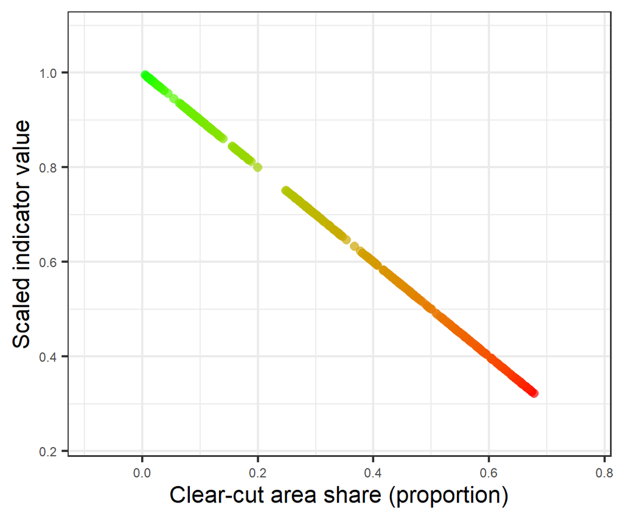

Figure 1: Linear normalisation of clear-cut area share (proportion) to indicator values (0–1), using national reference levels X0 = 100% and X100 = 0%. Points are 500 sampled bootstrap draws for the reporting period 2020–2024.

```r
norm_plot_data <- county_draws_scaled |>
  dplyr::slice_sample(n = min(500, nrow(county_draws_scaled)))

aifh_norm_plot <- ec_norm_plot(norm_plot_data$non_scaled_value, norm_plot_data$scaled_value) +
  ggplot2::labs(
    x = "Clear-cut area share (proportion)",
    y = "Scaled indicator value"
  ) +
  ggplot2::theme(axis.text = ggplot2::element_text(size = 9))
aifh_norm_plot$layers[[1]]$aes_params$size <- 3

suppressMessages(
  ggsave(
    filename = here::here("img/aifh_norm_plot.png"),
    plot = aifh_norm_plot,
    scale = 1.5
  )
)

aifh_norm_plot
```

The scaled draws are then passed to `ecTools::ec_upscale()`, which propagates uncertainty through the spatial hierarchy. For each of 1000 Monte Carlo iterations, one draw is sampled per county and the area-weighted mean gives one regional value; a second `ec_upscale()` call repeats this from regions to national level.

**ec_upscale: county to region (compute once, save RDS)**

```r
aifh_mc_cache_deps <- c(
  lsk_data_file,
  here::here("R/functions.R"),
  here::here("R/NO_AIFH_001.qmd")
)
aifh_mc_rds_regional <- here::here("data/aifh_mc_regional.rds")

if (
  file.exists(aifh_mc_rds_regional) &&
  file.mtime(aifh_mc_rds_regional) >= max(file.mtime(aifh_mc_cache_deps), na.rm = TRUE)
) {
  aifh_mc_regional <- readRDS(aifh_mc_rds_regional)
} else {
  aifh_mc_regional <- ecTools::ec_upscale(
    data        = county_draws_scaled,
    variable    = scaled_value,
    weight      = total_area,
    start_units = fylke_name,
    end_units   = region_code,
    year        = period,
    end_units_name = "region_code",
    n = 1000
  )
  saveRDS(aifh_mc_regional, aifh_mc_rds_regional)
}
```

**ec_upscale: region to national (compute once, save RDS)**

```r
region_area_weights <- county_draws_scaled |>
  dplyr::distinct(period, fylke_name, total_area, region_code) |>
  dplyr::group_by(period, region_code) |>
  dplyr::summarise(region_area = sum(total_area), .groups = "drop")

aifh_mc_regional_for_national <- aifh_mc_regional |>
  dplyr::left_join(region_area_weights, by = c("period", "region_code")) |>
  dplyr::mutate(nation = "National")

aifh_mc_rds_national <- here::here("data/aifh_mc_national.rds")

if (
  file.exists(aifh_mc_rds_national) &&
  file.mtime(aifh_mc_rds_national) >= max(
    c(file.mtime(aifh_mc_cache_deps), file.mtime(aifh_mc_rds_regional)),
    na.rm = TRUE
  )
) {
  aifh_mc_national <- readRDS(aifh_mc_rds_national)
} else {
  aifh_mc_national <- ecTools::ec_upscale(
    data        = aifh_mc_regional_for_national,
    variable    = sampled_mean,
    weight      = region_area,
    start_units = region_code,
    end_units   = nation,
    year        = period,
    end_units_name = "nation",
    n = 1000
  )
  saveRDS(aifh_mc_national, aifh_mc_rds_national)
}
```

**Combine regional and national MC draws; build summary tables**

```r
aifh_mc_combined <- dplyr::bind_rows(
  aifh_mc_regional |> dplyr::select(period, region = region_code, sampled_mean),
  aifh_mc_national |> dplyr::select(period, region = nation, sampled_mean)
)

county_scaled_all_periods <- aifh_results_county_all_periods |>
  dplyr::mutate(
    scaled_value = ec_normalise(indicator_value, x0 = x0, x100 = x100, fun = "linear")
  )

region_scaled_agg_all_periods <- aifh_mc_regional |>
  dplyr::group_by(period, region_code) |>
  dplyr::summarise(scaled_value = median(sampled_mean), .groups = "drop") |>
  dplyr::mutate(region_name = assign_region_name(region_code))

national_scaled_agg_all_periods <- aifh_mc_national |>
  dplyr::group_by(period) |>
  dplyr::summarise(scaled_value = median(sampled_mean), .groups = "drop") |>
  dplyr::mutate(region = "National")

region_scaled_agg_with_uncertainty <- aifh_mc_regional |>
  dplyr::group_by(period, region_code) |>
  dplyr::summarise(
    median = median(sampled_mean),
    p_025  = as.numeric(quantile(sampled_mean, 0.025)),
    p_25   = as.numeric(quantile(sampled_mean, 0.25)),
    p_75   = as.numeric(quantile(sampled_mean, 0.75)),
    p_975  = as.numeric(quantile(sampled_mean, 0.975)),
    .groups = "drop"
  ) |>
  dplyr::mutate(region_name = assign_region_name(region_code)) |>
  dplyr::left_join(
    aifh_results_region_all_periods |> dplyr::select(period, region_code, total_area, n_plots),
    by = c("period", "region_code")
  )

national_scaled_agg_with_uncertainty <- aifh_mc_national |>
  dplyr::group_by(period) |>
  dplyr::summarise(
    median = median(sampled_mean),
    p_025  = as.numeric(quantile(sampled_mean, 0.025)),
    p_25   = as.numeric(quantile(sampled_mean, 0.25)),
    p_75   = as.numeric(quantile(sampled_mean, 0.75)),
    p_975  = as.numeric(quantile(sampled_mean, 0.975)),
    .groups = "drop"
  ) |>
  dplyr::mutate(region = "National") |>
  dplyr::left_join(
    aifh_results_national_all_periods |> dplyr::select(period, total_area, n_plots),
    by = "period"
  )
```

The figure below (Figure 2) summarises regional and national indicator values for the reporting period 2020–2024. When additional periods are enabled in `reporting_periods`, the same plot will show values across periods.

**Time series of indicator values by region and period**

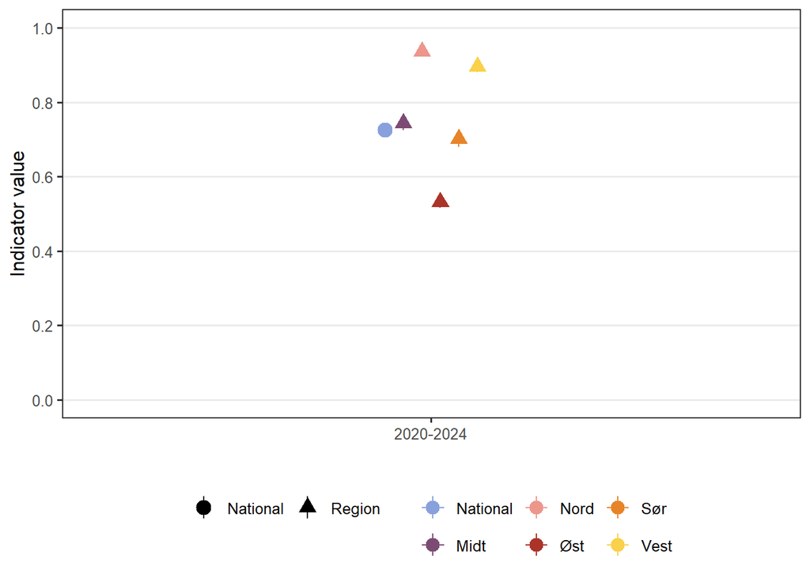

Figure 2: Indicator values for share of forest area without clear-cutting by region for the reporting period 2020–2024. Points show the MC median; error bars are 95% credible intervals from the Monte Carlo propagation. National values use filled circles and a thicker line.

```r
aifh_region_labels <- c(
  "1" = "Øst", "2" = "Sør", "3" = "Vest",
  "4" = "Midt", "5" = "Nord", "National" = "National"
)
aifh_region_levels <- c("National", "Midt", "Nord", "Øst", "Sør", "Vest")
aifh_region_cols <- setNames(
  MetBrewer::met.brewer("Archambault", n = length(aifh_region_levels)),
  aifh_region_levels
)

aifh_plot_data <- aifh_mc_combined |>
  dplyr::mutate(
    region_name = dplyr::recode(region, !!!aifh_region_labels),
    series_type = dplyr::if_else(region == "National", "National", "Region")
  ) |>
  dplyr::group_by(period, region_name, series_type) |>
  dplyr::summarise(
    median = median(sampled_mean),
    p_025  = as.numeric(quantile(sampled_mean, 0.025)),
    p_975  = as.numeric(quantile(sampled_mean, 0.975)),
    .groups = "drop"
  ) |>
  dplyr::mutate(region_name = factor(region_name, levels = aifh_region_levels))

ggplot2::ggplot(
  aifh_plot_data,
  ggplot2::aes(x = period, y = median, colour = region_name, group = region_name)
) +
  ggplot2::geom_line(
    ggplot2::aes(linewidth = series_type),
    position = ggplot2::position_dodge(width = 0.18)
  ) +
  ggplot2::geom_pointrange(
    ggplot2::aes(ymin = p_025, ymax = p_975, shape = series_type),
    size = 0.8, linewidth = 0.45,
    position = ggplot2::position_dodge(width = 0.18)
  ) +
  ggplot2::scale_colour_manual(values = aifh_region_cols, name = NULL) +
  ggplot2::scale_shape_manual(values = c(National = 19, Region = 17), name = NULL) +
  ggplot2::scale_linewidth_manual(values = c(National = 1, Region = 0.55), guide = "none") +
  ggplot2::scale_y_continuous(limits = c(0, 1), breaks = seq(0, 1, 0.2)) +
  ggplot2::theme_bw(base_size = 12) +
  ggplot2::theme(
    legend.position    = "bottom",
    legend.box         = "horizontal",
    panel.grid.minor   = ggplot2::element_blank(),
    panel.grid.major.x = ggplot2::element_blank()
  ) +
  ggplot2::guides(
    colour = ggplot2::guide_legend(
      nrow = 2,
      override.aes = list(size = 0.7, linewidth = 0.45)
    ),
    shape  = ggplot2::guide_legend(override.aes = list(size = 0.8, linewidth = 0.45))
  ) +
  ggplot2::labs(y = "Indicator value", x = "")
```

## 10. Results

The following tables present scaled indicator results at county, regional, and national scales for the reporting period 2020–2024. Tables report the median as the indicator value, with an approximate 95% interval (2.5% and 97.5% quantiles) and an approximate interquartile range (25% and 75% quantiles). All scaled values are on a 0–1 scale, where 0 corresponds to X0 (100% clear-cut area share) and 1 corresponds to X100 (0% clear-cut area share).

### 10.1 County-level results (scaled with uncertainty)

Use the search box and page controls in Table 3 to browse county rows for the reporting period 2020–2024.

Table 3: County indicator values for share of forest area without clear-cutting for the reporting period 2020–2024. Values are scaled to 0–1 using national X0 and X100. Uncertainty is derived from 1000 bootstrap draws. The median is reported as the indicator value, with approximate 95% and interquartile intervals from the scaled draw distribution.

| ECT | Indicator | ID | Accounting area | Region | Ecosystem | Reporting period | Indicator value | 95% CI | 50% CI | Number of plots |
| --- | --- | --- | --- | --- | --- | --- | --- | --- | --- | --- |
| C1 | Share of forest area without clear-cutting | NO_AIFH_001 | Buskerud | Øst | Boreal/montane forests | 2020-2024 | 0.56 | 0.52 - 0.59 | 0.54 - 0.57 | 860 |
| C1 | Share of forest area without clear-cutting | NO_AIFH_001 | Hedmark | Øst | Boreal/montane forests | 2020-2024 | 0.54 | 0.52 - 0.56 | 0.53 - 0.55 | 1912 |
| C1 | Share of forest area without clear-cutting | NO_AIFH_001 | Oppland | Øst | Boreal/montane forests | 2020-2024 | 0.59 | 0.56 - 0.63 | 0.58 - 0.61 | 1085 |
| C1 | Share of forest area without clear-cutting | NO_AIFH_001 | Oslo og Akershus | Øst | Boreal/montane forests | 2020-2024 | 0.35 | 0.31 - 0.4 | 0.34 - 0.37 | 428 |
| C1 | Share of forest area without clear-cutting | NO_AIFH_001 | Vestfold | Øst | Boreal/montane forests | 2020-2024 | 0.43 | 0.35 - 0.5 | 0.4 - 0.45 | 176 |
| C1 | Share of forest area without clear-cutting | NO_AIFH_001 | Østfold | Øst | Boreal/montane forests | 2020-2024 | 0.46 | 0.41 - 0.51 | 0.44 - 0.48 | 329 |
| C1 | Share of forest area without clear-cutting | NO_AIFH_001 | Agder | Sør | Boreal/montane forests | 2020-2024 | 0.73 | 0.7 - 0.75 | 0.72 - 0.74 | 997 |
| C1 | Share of forest area without clear-cutting | NO_AIFH_001 | Telemark | Sør | Boreal/montane forests | 2020-2024 | 0.68 | 0.64 - 0.71 | 0.67 - 0.69 | 909 |
| C1 | Share of forest area without clear-cutting | NO_AIFH_001 | Hordaland | Vest | Boreal/montane forests | 2020-2024 | 0.89 | 0.86 - 0.92 | 0.88 - 0.9 | 516 |
| C1 | Share of forest area without clear-cutting | NO_AIFH_001 | Rogaland | Vest | Boreal/montane forests | 2020-2024 | 0.91 | 0.87 - 0.94 | 0.9 - 0.92 | 260 |

[output cut: 6 more lines]

### 10.2 Regional results (scaled with uncertainty)

Table 4: Regional indicator values for share of forest area without clear-cutting for the reporting period 2020–2024. Scaled values and uncertainty are derived from Monte Carlo propagation (1000 draws per region). The median is reported as the indicator value, with approximate 95% and interquartile intervals from the MC distribution.

| ECT | Indicator | ID | Accounting area | Ecosystem | Reporting period | Indicator value | 95% CI | 50% CI | Number of plots |
| --- | --- | --- | --- | --- | --- | --- | --- | --- | --- |
| C1 | Share of forest area without clear-cutting | NO_AIFH_001 | Øst | Boreal/montane forests | 2020-2024 | 0.53 | 0.52 - 0.55 | 0.53 - 0.54 | 4,790 |
| C1 | Share of forest area without clear-cutting | NO_AIFH_001 | Sør | Boreal/montane forests | 2020-2024 | 0.70 | 0.68 - 0.72 | 0.69 - 0.71 | 1,906 |
| C1 | Share of forest area without clear-cutting | NO_AIFH_001 | Vest | Boreal/montane forests | 2020-2024 | 0.90 | 0.88 - 0.91 | 0.89 - 0.9 | 1,266 |
| C1 | Share of forest area without clear-cutting | NO_AIFH_001 | Midt | Boreal/montane forests | 2020-2024 | 0.74 | 0.72 - 0.76 | 0.74 - 0.75 | 2,386 |
| C1 | Share of forest area without clear-cutting | NO_AIFH_001 | Nord | Boreal/montane forests | 2020-2024 | 0.94 | 0.92 - 0.95 | 0.93 - 0.94 | 2,240 |

### 10.3 National results (scaled with uncertainty)

Table 5: National indicator values for share of forest area without clear-cutting for the reporting period 2020–2024. Scaled values and uncertainty are derived from Monte Carlo propagation (1000 draws). The median is reported as the indicator value, with approximate 95% and interquartile intervals from the MC distribution.

| ECT | Indicator | ID | Accounting area | Ecosystem | Reporting period | Indicator value | 95% CI | 50% CI | Number of plots |
| --- | --- | --- | --- | --- | --- | --- | --- | --- | --- |
| C1 | Share of forest area without clear-cutting | NO_AIFH_001 | National | Boreal/montane forests | 2020-2024 | 0.73 | 0.72 - 0.73 | 0.72 - 0.73 | 12,588 |

## 11. Export file

Regional and national Monte Carlo draws are exported in one table (`aifh_mc_combined`: `period`, `region`, `sampled_mean`; `region` contains the five NI region codes and `"National"`).

**Export regional and national MC-propagated indicator draws**

```r
write.csv(
  aifh_mc_combined,
  here::here("data/results_NO_AIFH_001.csv"),
  row.names = FALSE
)
```

## 12. Author contributions

**CRediT statement**

- Conceptualization: [UJA, KOS]
- Methodology: [UJA, KOS, AHH]
- Data curation: [OS]
- Formal analysis: [AHH]
- Validation: [AHH, OS, KOS]
- Visualization: [AHH]
- Writing – original draft: [AHH, UJA]
- Writing – review & editing: [All]

**MeRIT attribution**

This part supplements the CRediT statement with more granularity for method section.

**Session Info**

This workflow uses `renv`. Run `renv::restore()` to recreate the working environment.